# DATA-413/613: HW on List Columns and COVID19

# 6 Get World Population Data

1.a. Use `vroom::vroom()` with a relative path to read in the zipped .csv file with World population data for 1950-2100 into its own data frame called `df_pop`.

- The data is from the [UN](https://population.un.org/wpp/Download/Standard/CSV/) which uses different country names in many cases from the COVID data. It also uses a different structure for separating countries and territories.
- Note: the UN population data is in thousands so it can have fractional values.
- Filter the data to only those rows for 2022 where the scenario variant is “No change” and which have a valid `ISO3_code`,
- Select `Time`, `Location`, `ISO3_code`, `PopTotal`, `PopDensity` and save to `df_pop`.
  - You should have 237 rows remaining out of the 586,092 rows.

```r
library(vroom)
vroom("data/WPP2022_TotalPopulationBySex.csv.zip") -> df_pop
```

```
## Multiple files in zip: reading 'WPP2022_TotalPopulationBySex.csv'
##
```

```r
df_pop %>%
  filter(Time == 2022) %>%  #filter year 2022
  filter(Variant == "No change") %>% #variant no change
  filter(!is.na(ISO3_code)) %>% #has a valid ISO
  select(Time, Location, ISO3_code, PopTotal, PopDensity) -> df_pop

nrow(df_pop) #correct number of rows
```

```
## [1] 237
```

2. Show the countries (`Country_Region`) in the Covid data that are not in the population data - Use `ISO3_code`. How many are there?

```r
#all rows from x w/ out match in Y
anti_join(df_all, df_pop) -> df_test
unique(df_test$Country_Region)
```

```
## [1] "Antarctica"           "Diamond Princess"     "Kosovo"
## [4] "MS Zaandam"           "Micronesia"           "Summer Olympics 2020"
## [7] "Winter Olympics 2022"
```

There are 7 countries in the COVID data that are not in the population data.

3. Identify the countries in the population data that are not in the covid data. Use `ISO3_code` How many are there?

```r
anti_join(df_pop, df_all) -> df_test
unique(df_test$Location)
```

```
##  [1] "Mayotte"                          "Réunion"
##  [3] "Western Sahara"                   "Saint Helena"
##  [5] "Turkmenistan"                     "China, Hong Kong SAR"
##  [7] "China, Macao SAR"                 "Faroe Islands"
##  [9] "Guernsey"                         "Isle of Man"
## [11] "Jersey"                           "Gibraltar"
## [13] "Kosovo (under UNSC res. 1244)"    "Anguilla"
## [15] "Aruba"                            "Bonaire, Sint Eustatius and Saba"
## [17] "British Virgin Islands"           "Cayman Islands"
## [19] "Curaçao"                          "Guadeloupe"
## [21] "Martinique"                       "Montserrat"
## [23] "Puerto Rico"                      "Saint Barthélemy"
## [25] "Saint Martin (French part)"       "Sint Maarten (Dutch part)"
## [27] "Turks and Caicos Islands"         "United States Virgin Islands"
## [29] "Falkland Islands (Malvinas)"      "French Guiana"
## [31] "Bermuda"                          "Greenland"
## [33] "Saint Pierre and Miquelon"        "New Caledonia"
## [35] "Guam"                             "Micronesia (Fed. States of)"
## [37] "Northern Mariana Islands"         "American Samoa"
## [39] "Cook Islands"                     "French Polynesia"
## [41] "Niue"                             "Tokelau"
## [43] "Wallis and Futuna Islands"
```

There are 43 countries in the population data that are not in the COVID data.

4. What is the percentage of the world population contained in the countries not in the covid data?

```r
sum(df_test$PopTotal) -> not_in_covid #sum of pop of countries not in COVID data
sum(df_pop$PopTotal) -> total_pop #total pop

(not_in_covid / total_pop) * 100
```

```
## [1] 0.3089145
```

About .3% of the world population is contained in countries not in the COVID data.

2. Use a {dplyr} join to remove all Locations from `df_pop` that are not in the `df_all` data frame.
- Add variables to `df_pop` for the rank for each location for population (`rank_p`) and the rank for population density (`rank_d`).
- Calculate rank using `dplyr:min_rank()` so the country with the largest value is number 1 for that variable.
- Save to `df_pop`.

```r
#return all rows from x with a match in y.
semi_join(df_pop, df_all) -> df_pop
#rank
df_pop %>%
  mutate(rank_p = min_rank(desc(PopTotal)),
         rank_d = min_rank(desc(PopDensity)),
         #adding in full measure, b/c per note population in thousands
         PopTotal_revised = PopTotal*1000) -> df_pop
head(df_pop)
```

```
## # A tibble: 6 × 8
##    Time Location ISO3_code PopTotal PopDensity rank_p rank_d PopTotal_revised
##   <dbl> <chr>    <chr>        <dbl>      <dbl>  <int>  <int>            <dbl>
## 1  2022 Burundi  BDI         12890.      497.      78     18         12889576
## 2  2022 Comoros  COM           837.      450.     159     20           836774
## 3  2022 Djibouti DJI          1121.       48.4    157    137          1120849
## 4  2022 Eritrea  ERI          3684.       30.4    130    151          3684032
## 5  2022 Ethiopia ETH        123380.      123.      12     73        123379924
## 6  2022 Kenya    KEN         54027.       93.0     27     96         54027487
```

3. Show the countries with rank 1:10 for Total Population
- Then show the countries with rank 1:10 for Population Density.

```r
df_pop %>%
  slice_min(rank_p, n = 10) #countries with rank 1:10 for total pop
```

```
## # A tibble: 10 × 8
##     Time Location                 ISO3_c…¹ PopTo…² PopDe…³ rank_p rank_d PopTo…⁴
##    <dbl> <chr>                    <chr>      <dbl>   <dbl>  <int>  <int>   <dbl>
##  1  2022 China                    CHN       1.43e6  149.        1     61  1.43e9
##  2  2022 India                    IND       1.42e6  477.        2     19  1.42e9
##  3  2022 United States of America USA       3.38e5   37.0       3    146  3.38e8
##  4  2022 Indonesia                IDN       2.76e5  144.        4     64  2.76e8
##  5  2022 Pakistan                 PAK       2.36e5  306.        5     30  2.36e8
##  6  2022 Nigeria                  NGA       2.19e5  240.        6     40  2.19e8
##  7  2022 Brazil                   BRA       2.15e5   25.8       7    161  2.15e8
##  8  2022 Bangladesh               BGD       1.71e5 1315.        8      6  1.71e8
##  9  2022 Russian Federation       RUS       1.45e5    8.84      9    183  1.45e8
## 10  2022 Mexico                   MEX       1.28e5   65.1      10    121  1.28e8
## # … with abbreviated variable names ¹ISO3_code, ²PopTotal, ³PopDensity,
## #   ⁴PopTotal_revised
```

```r
df_pop %>%
  slice_min(rank_d, n = 10) #countries with rank 1:10 for total density
```

```
## # A tibble: 10 × 8
##     Time Location                  ISO3_…¹ PopTo…² PopDe…³ rank_p rank_d PopTo…⁴
##    <dbl> <chr>                     <chr>     <dbl>   <dbl>  <int>  <int>   <dbl>
##  1  2022 Monaco                    MCO     3.65e+1  24476.    189      1  3.65e4
##  2  2022 Singapore                 SGP     5.98e+3   8749.    111      2  5.98e6
##  3  2022 Bahrain                   BHR     1.47e+3   1880.    151      3  1.47e6
##  4  2022 Maldives                  MDV     5.24e+2   1746.    168      4  5.24e5
##  5  2022 Malta                     MLT     5.33e+2   1693.    167      5  5.33e5
##  6  2022 Bangladesh                BGD     1.71e+5   1315.      8      6  1.71e8
##  7  2022 Holy See                  VAT     5.1 e-1   1160.    194      7  5.1 e2
##  8  2022 State of Palestine        PSE     5.25e+3    872.    120      8  5.25e6
##  9  2022 China, Taiwan Province o… TWN     2.39e+4    675.     57      9  2.39e7
## 10  2022 Barbados                  BRB     2.82e+2    655.    174     10  2.82e5
## # … with abbreviated variable names ¹ISO3_code, ²PopTotal, ³PopDensity,
## #   ⁴PopTotal_revised
```

# 7 Add Population Data to `df_all`

- Use a {dplyr} join to add the data from `df_pop` to `df_all` to create `df_allp` for only those countries in `df_all` even if they are not in `df_pop`.

```r
left_join(df_all, df_pop) -> df_allp
glimpse(df_allp)
```

```
## Rows: 594,184
## Columns: 15
## $ case_type        <fct> confirmed, confirmed, confirmed, confirmed, confirmed…
## $ Country_Region   <chr> "Afghanistan", "Afghanistan", "Afghanistan", "Afghani…
## $ Country_State    <chr> "Afghanistan", "Afghanistan", "Afghanistan", "Afghani…
## $ Province_State   <chr> NA, NA, NA, NA, NA, NA, NA, NA, NA, NA, NA, NA, NA, N…
## $ Date             <date> 2020-01-22, 2020-01-23, 2020-01-24, 2020-01-25, 2020…
## $ Daily_Total      <dbl> 0, 0, 0, 0, 0, 0, 0, 0, 0, 0, 0, 0, 0, 0, 0, 0, 0, 0,…
## $ Continent        <chr> "Asia", "Asia", "Asia", "Asia", "Asia", "Asia", "Asia…
## $ ISO3_code        <chr> "AFG", "AFG", "AFG", "AFG", "AFG", "AFG", "AFG", "AFG…
## $ Time             <dbl> 2022, 2022, 2022, 2022, 2022, 2022, 2022, 2022, 2022,…
## $ Location         <chr> "Afghanistan", "Afghanistan", "Afghanistan", "Afghani…
## $ PopTotal         <dbl> 41128.77, 41128.77, 41128.77, 41128.77, 41128.77, 411…
## $ PopDensity       <dbl> 63.344, 63.344, 63.344, 63.344, 63.344, 63.344, 63.34…
## $ rank_p           <int> 36, 36, 36, 36, 36, 36, 36, 36, 36, 36, 36, 36, 36, 3…
## $ rank_d           <int> 123, 123, 123, 123, 123, 123, 123, 123, 123, 123, 123…
## $ PopTotal_revised <dbl> 41128771, 41128771, 41128771, 41128771, 41128771, 411…
```

# 8 How many `Country_Regions` have Multiple `Country_States`?

- The data does not treat all countries the same with regard to reporting at the country level or at the province or region level.
- Some countries are reported with *totals only at the country level* (`Country_Region`),
- Some countries are reported with *totals only at the state/province level* (`Province_State`),
- Some countries are reported with *totals for the country and for separate state/provinces* for the country.
- We can use the `Country States` and `Country Region` variables to figure out what this means.
1. For each `Country Region` calculate the number of `Country States` for *distinct combinations of `Country States` and `Country Region`* and then,
- show in descending order the number of `Country_States`for each `Country_Region` where the number of `Country_States` is greater than 1.

```r
df_all %>%
  select(Country_Region, Country_State) %>%
  distinct() %>%
  group_by(Country_Region) %>%
  summarize(`Number of Distinct Country_State` = n()) %>%
  filter(`Number of Distinct Country_State` > 1) %>%
  arrange(desc(`Number of Distinct Country_State`))
```

```
## # A tibble: 8 × 2
##   Country_Region `Number of Distinct Country_State`
##   <chr>                                       <int>
## 1 China                                          34
## 2 Canada                                         16
## 3 United Kingdom                                 15
## 4 France                                         12
## 5 Australia                                       8
## 6 Netherlands                                     5
## 7 Denmark                                         3
## 8 New Zealand                                     3
```

2. For each `Country Region` calculate the number of `Country States` for distinct combinations of `Country States` and `Country Region` where the `Country_Region` does **not have matching entries in `Country_State`** and then,
- show in descending order the number of `Country_States` for each `Country_Region`, show where the number of `Country_States` is greater than 1.

```r
df_all %>%
  select(Country_Region, Country_State) %>%
  distinct() %>% #distinct combinations
  filter(Country_Region != Country_State) %>% #does not have matching entries in Country_State
  group_by(Country_Region) %>%
  summarize(`Number of Distinct Country_State` = n()) %>%
  filter(`Number of Distinct Country_State` > 1) %>% #greater than 1
  arrange(desc(`Number of Distinct Country_State`)) #desc order
```

```
## # A tibble: 8 × 2
##   Country_Region `Number of Distinct Country_State`
##   <chr>                                       <int>
## 1 China                                          34
## 2 Canada                                         16
## 3 United Kingdom                                 14
## 4 France                                         11
## 5 Australia                                       8
## 6 Netherlands                                     4
## 7 Denmark                                         2
## 8 New Zealand                                     2
```

3. Explain what the difference between the two results suggests for future analysis of totals for each country represented in `Country_Region`.

This suggests that there is potential duplication of records. Specifically, a country may record all cases nationally, but then also break this national count down by local districts/provinces. For example, New Zealand has a Country_State for the national level, byt also two more Country_State combinations for sub-groups.

# 9 Analyze Data

1. Use `df_allp` to create a new data frame with data grouped by `Country_Region`, `Continent` `case_type`, `rank_p` and `rank_d` that summarizes the **current totals** and the **totals as a percentage of total population**.
- Create grand totals for each of the two global case types for both `df_all` and your new data frame and compare them.
- Interpret the results. **Check a website to confirm if your numbers are reasonable and show the URL you checked and the numbers.**

```r
#Building out first measure
df_allp %>%
 group_by(Country_Region, Continent, case_type, rank_p, rank_d) %>%
 summarise(totalCases = max(Daily_Total))
```

```
## 'rank_p'. You can override using the `.groups` argument.
```

```
## # A tibble: 402 × 6
## # Groups:   Country_Region, Continent, case_type, rank_p [402]
##    Country_Region Continent case_type rank_p rank_d totalCases
##    <chr>          <chr>     <fct>      <int>  <int>      <dbl>
##  1 Afghanistan    Asia      confirmed     36    123     204610
##  2 Afghanistan    Asia      deaths        36    123       7829
##  3 Albania        Europe    confirmed    135     86     333161
##  4 Albania        Europe    deaths       135     86       3594
##  5 Algeria        Africa    confirmed     34    169     270952
##  6 Algeria        Africa    deaths        34    169       6881
##  7 Andorra        Europe    confirmed    184     57      46664
##  8 Andorra        Europe    deaths       184     57        155
##  9 Angola         Africa    confirmed     42    153     103131
## 10 Angola         Africa    deaths        42    153       1917
## # … with 392 more rows
```

```r
#According to https://covid19.who.int/region/emro/country/af Afghanistan has ~204.5k cases and 7,829 deaths, cases are close enough to result / deaths match exactly
#According to https://covid19.who.int/region/afro/country/zw Zimbabwe has ~257.893 cases and 5,606 deaths, matches result exactly

#Adding in second measure
df_allp %>%
 group_by(Country_Region, Continent, case_type, rank_p, rank_d) %>%
 summarise(totalCases = max(Daily_Total),
           total_percent_pop = (totalCases/last(PopTotal_revised)*100)) %>%
  ungroup() -> cases_percents
```

```
## 'rank_p'. You can override using the `.groups` argument.
```

2. What are the 20 Countries with the most confirmed cases and what is the percentage of their total population affected?

```r
cases_percents %>%
group_by(Country_Region, total_percent_pop, totalCases) %>%
filter(case_type == "confirmed") %>%
arrange(desc(totalCases)) %>%
head(20) -> top_20_cases

top_20_cases
```

```
## # A tibble: 20 × 7
## # Groups:   Country_Region, total_percent_pop, totalCases [20]
##    Country_Region Continent case_type rank_p rank_d totalCases total_percent_pop
##    <chr>          <chr>     <fct>      <int>  <int>      <dbl>             <dbl>
##  1 US             Americas  confirmed      3    146   98045793             29.0
##  2 India          Asia      confirmed      2     19   44667390              3.15
##  3 France         Europe    confirmed     23     77   36145223             55.9
##  4 Germany        Europe    confirmed     19     42   36080574             43.3
##  5 Brazil         Americas  confirmed      7    161   34908198             16.2
##  6 Korea, South   Asia      confirmed     29     16   26290877             50.7
##  7 United Kingdom Europe    confirmed     21     34   23954192             35.5
##  8 Italy          Europe    confirmed     25     54   23823192             40.4
##  9 Japan          Asia      confirmed     11     28   23241410             18.8
## 10 Russia         Europe    confirmed      9    183   21198961             14.6
## 11 Turkey         Asia      confirmed     18     81   16919638             19.8
## 12 Spain          Europe    confirmed     30     94   13551539             28.5
## 13 Vietnam        Asia      confirmed     16     29   11508893             11.7
## 14 Argentina      Americas  confirmed     33    177    9721718             21.4
## 15 Netherlands    Europe    confirmed     71     17    8528384             48.6
## 16 Taiwan*        Asia      confirmed     57      9    8050901             33.7
## 17 Iran           Asia      confirmed     17    132    7559001              8.54
## 18 Mexico         Americas  confirmed     10    121    7118933              5.58
## 19 Indonesia      Asia      confirmed      4     64    6565912              2.38
## 20 Poland         Europe    confirmed     37     70    6346397             15.9
```

3. What are the 20 Countries with the most deaths and what is the percentage of their total population affected?

```r
cases_percents %>%
group_by(Country_Region, total_percent_pop, totalCases) %>%
filter(case_type == "deaths") %>%
arrange(desc(totalCases)) %>%
head(20) -> top_20_deaths

top_20_deaths
```

```
## # A tibble: 20 × 7
## # Groups:   Country_Region, total_percent_pop, totalCases [20]
##    Country_Region Continent case_type rank_p rank_d totalCases total_percent_pop
##    <chr>          <chr>     <fct>      <int>  <int>      <dbl>             <dbl>
##  1 US             Americas  deaths         3    146    1074701            0.318
##  2 Brazil         Americas  deaths         7    161     688656            0.320
##  3 India          Asia      deaths         2     19     530533            0.0374
##  4 Russia         Europe    deaths         9    183     383195            0.265
##  5 Mexico         Americas  deaths        10    121     330444            0.259
##  6 Peru           Americas  deaths        44    157     217294            0.638
##  7 United Kingdom Europe    deaths        21     34     210680            0.312
##  8 Italy          Europe    deaths        25     54     179985            0.305
##  9 Indonesia      Asia      deaths         4     64     159158            0.0578
## 10 Germany        Europe    deaths        19     42     155807            0.187
## 11 France         Europe    deaths        23     77     154284            0.239
## 12 Iran           Asia      deaths        17    132     144613            0.163
## 13 Colombia       Americas  deaths        28    139     141862            0.273
## 14 Argentina      Americas  deaths        33    177     130011            0.286
## 15 Poland         Europe    deaths        37     70     118210            0.297
## 16 Ukraine        Europe    deaths        38    120     118190            0.298
## 17 Spain          Europe    deaths        30     94     115422            0.243
## 18 South Africa   Africa    deaths        24    136     102371            0.171
## 19 Turkey         Asia      deaths        18     81     101203            0.119
## 20 Romania        Europe    deaths        64    101      67237            0.342
```

4. Describe the results based on the totals with the rankings for total population and population density.

Even though some countries are not particularly dense, they still experienced a significant amount of deaths. This is true for the US, Brazil, Peru, and Russia. As for cases, higher rankings in population generally align with more cases, however, the degree to which cases impacted the total percent of the population varies by country.

# 10 High Percentage but Low Totals Countries

- Which countries in the top 20 for percentage of population for cases are **Not** in the top 20 for the absolute number of cases.
- Which countries in the top 20 for percentage of population for deaths are **Not** in the top 20 for the absolute number deaths?
- Describe the results based on the per population results with the rankings for total population and population density.

```r
#in top 20 for %, not in absolute
cases_percents %>%
group_by(Country_Region, total_percent_pop, totalCases) %>%
filter(case_type == "confirmed") %>%
mutate(total_percent_pop = total_percent_pop / 1000) %>% #UN data in thousands
arrange(desc(total_percent_pop)) %>%
head(n = 20) -> top_20_cases_percent

data.frame(top_20_cases[1], top_20_cases_percent[1]) %>%
rename("Country_Region_Absolute" = "Country_Region",
       "Country_Region_Percent" = "Country_Region.1") %>%
mutate(in_percent_not_in_abs = !(Country_Region_Percent %in% Country_Region_Absolute)) %>%
select(-Country_Region_Absolute) %>%
filter(in_percent_not_in_abs == TRUE)
```

```
##    Country_Region_Percent in_percent_not_in_abs
## 1              San Marino                  TRUE
## 2                 Austria                  TRUE
## 3                Slovenia                  TRUE
## 4                 Andorra                  TRUE
## 5                 Denmark                  TRUE
## 6                 Iceland                  TRUE
## 7                  Brunei                  TRUE
## 8                Portugal                  TRUE
## 9           Liechtenstein                  TRUE
## 10                 Israel                  TRUE
## 11                 Latvia                  TRUE
## 12                 Greece                  TRUE
## 13            Switzerland                  TRUE
## 14                 Cyprus                  TRUE
## 15                Georgia                  TRUE
## 16                Bahrain                  TRUE
## 17             Luxembourg                  TRUE
```

```r
#looking at the rankings
data.frame(top_20_cases[1], top_20_cases_percent[1]) %>%
rename("Country_Region_Absolute" = "Country_Region",
       "Country_Region_Percent" = "Country_Region.1") %>%
mutate(in_percent_not_in_abs = !(Country_Region_Percent %in% Country_Region_Absolute)) %>%
select(-Country_Region_Absolute) %>%
filter(in_percent_not_in_abs == TRUE) %>%
select(Country_Region_Percent) %>%
rename("Country_Region" = "Country_Region_Percent") -> rankings_comparison

left_join(rankings_comparison, top_20_cases_percent) -> rankings_comparison
rankings_comparison %>%
select(Country_Region, rank_p, rank_d)
```

```
##    Country_Region rank_p rank_d
## 1      San Marino    190     14
## 2         Austria     99     83
## 3        Slovenia    145     84
## 4         Andorra    184     57
## 5         Denmark    113     66
## 6         Iceland    172    191
## 7          Brunei    169    110
## 8        Portugal     92     79
## 9   Liechtenstein    188     39
## 10         Israel     98     22
## 11         Latvia    148    152
## 12         Greece     90    108
## 13    Switzerland    101     49
## 14         Cyprus    155     68
## 15        Georgia    129    133
## 16        Bahrain    151      3
## 17     Luxembourg    163     38
```

The countries that are in the percent but not absolute for top 20 cases, tend to have higher density rankings (more density) with relatively lower population rankings (less population). This makes sense because in countries that are smaller, more dense, with less people – a comparatively small amount of cases will represent a larger chunk of the population.

```r
cases_percents %>%
group_by(Country_Region, total_percent_pop, totalCases) %>%
filter(case_type == "deaths") %>%
mutate(total_percent_pop = total_percent_pop / 1000) %>% #UN data in thousands
arrange(desc(total_percent_pop)) %>%
head(n = 20) -> top_20_deaths_percent


data.frame(top_20_deaths[1], top_20_deaths_percent[1]) %>%
rename("Country_Region_Absolute" = "Country_Region",
       "Country_Region_Percent" = "Country_Region.1") %>%
mutate(in_percent_not_in_abs = !(Country_Region_Percent %in% Country_Region_Absolute)) %>%
select(-Country_Region_Absolute) %>%
filter(in_percent_not_in_abs == TRUE)
```

```
##    Country_Region_Percent in_percent_not_in_abs
## 1                Bulgaria                  TRUE
## 2  Bosnia and Herzegovina                  TRUE
## 3                 Hungary                  TRUE
## 4         North Macedonia                  TRUE
## 5                 Georgia                  TRUE
## 6              Montenegro                  TRUE
## 7                 Croatia                  TRUE
## 8                 Czechia                  TRUE
## 9                Slovakia                  TRUE
## 10                Moldova                  TRUE
## 11             San Marino                  TRUE
## 12              Lithuania                  TRUE
## 13                 Latvia                  TRUE
## 14                 Greece                  TRUE
## 15               Slovenia                  TRUE
## 16                  Chile                  TRUE
```

```r
#rankings
data.frame(top_20_deaths[1], top_20_deaths_percent[1]) %>%
rename("Country_Region_Absolute" = "Country_Region",
       "Country_Region_Percent" = "Country_Region.1") %>%
mutate(in_percent_not_in_abs = !(Country_Region_Percent %in% Country_Region_Absolute)) %>%
select(-Country_Region_Absolute) %>%
filter(in_percent_not_in_abs == TRUE) %>%
select(Country_Region_Percent) %>%
rename("Country_Region" = "Country_Region_Percent") -> rankings_comparison
left_join(rankings_comparison, top_20_deaths_percent) -> rankings_comparison
rankings_comparison %>%
select(Country_Region, rank_p, rank_d)
```

```
##            Country_Region rank_p rank_d
## 1                Bulgaria    107    125
## 2  Bosnia and Herzegovina    134    124
## 3                 Hungary     94     82
## 4         North Macedonia    147    102
## 5                 Georgia    129    133
## 6              Montenegro    164    140
## 7                 Croatia    128    117
## 8                 Czechia     88     67
## 9                Slovakia    114     78
## 10                Moldova    133     90
## 11             San Marino    190     14
## 12              Lithuania    138    141
## 13                 Latvia    148    152
## 14                 Greece     90    108
## 15               Slovenia    145     84
## 16                  Chile     65    159
```

# 11 Plotting the Data (Extra Credit)

- Create two plots, one for the number of cases, and one for the number of deaths, showing the changes **over time**.
- Limit to the top 20 `Country_Region` for highest cases and then for highest deaths
- Show each country and facet by continent with the same scale for the y axis.
- Use a log scale for the y axis.
- Interpret each plot with respect to the total cases (or deaths) and the path of cases (or deaths) across and within different continents.

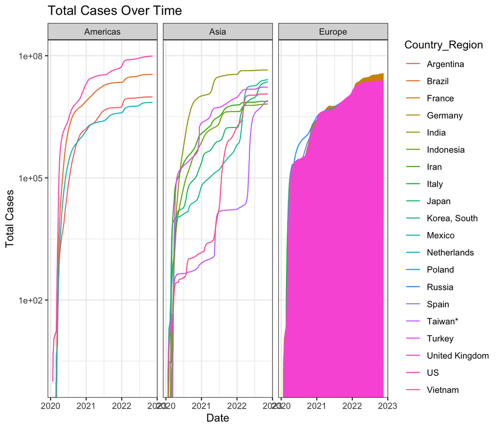

```r
#attempt
as_vector(top_20_cases[1]) -> confirmed_20_countries

df_allp %>%
  filter(case_type == "confirmed", Country_Region %in% confirmed_20_countries) %>%
  ggplot(mapping = aes(x = Date, y = Daily_Total)) +
  geom_line(aes(color = Country_Region)) +
  facet_wrap(~Continent) +
  scale_y_log10() +
  theme_bw() +
  ylab("Total Cases") +
  ggtitle("Total Cases Over Time")
```

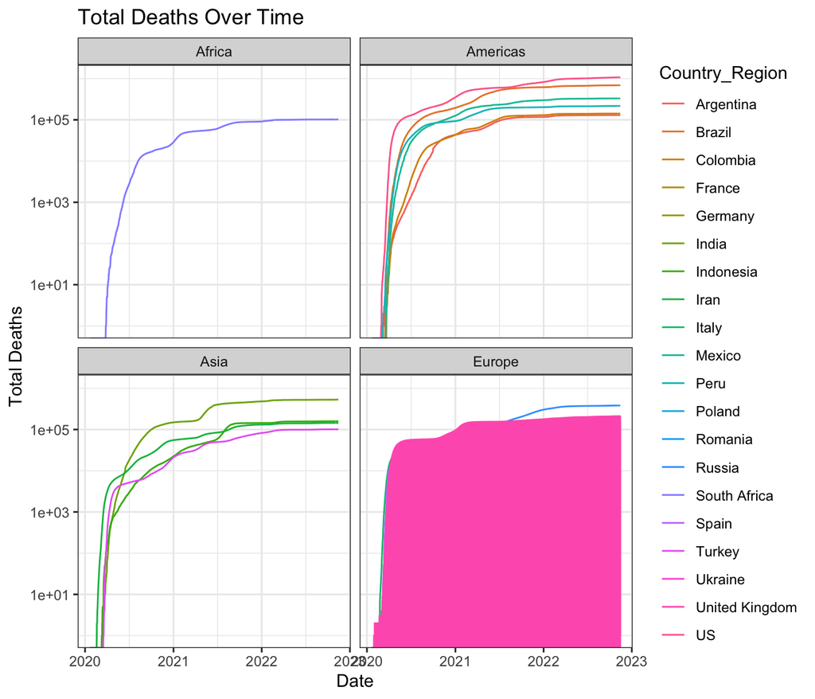

```r
as_vector(top_20_deaths[1]) -> deaths_20_countries
df_allp %>%
  filter(case_type == "deaths", Country_Region %in% deaths_20_countries) %>%
  ggplot(mapping = aes(x = Date, y = Daily_Total)) +
  geom_line(aes(color = Country_Region)) +
  facet_wrap(~Continent) +
  scale_y_log10() +
  theme_bw() +
  ylab("Total Deaths") +
  ggtitle("Total Deaths Over Time")
```